# Course 8 Week 4

AV

September 17, 2017

## 1. Load necesarry libraries, import csv’s.

Load libraries.

```r
options(warn=-1)
require(randomForest)
require(caret)
require(e1071)
require(ggplot2)
require(data.table)
```

The training dataset is taken from: https://d396qusza40orc.cloudfront.net/predmachlearn/pml-training.csv

The test dataset is taken from: https://d396qusza40orc.cloudfront.net/predmachlearn/pml-testing.csv

```r
wd <- "D:/Dropbox/project/coursera/r/c8w04"
testf <- "pml-testing.csv"
trainf <- "pml-training.csv"
testcsv <- read.csv(testf)
traincsv <- read.csv(trainf, na.strings = "#DIV/0!") #remove observations that start with "#div/0!" when reading the CSV file, this is discovered later when exploring the data.
ds <- traincsv #set ds as dataset to work with
```

## 2. Explore & clean data

```r
##ecplore data
dim(ds)
str(ds)
data.frame(sapply(ds, function(y) sum(length(which(is.na(y)))))) #check which variables have too many NA's
```

The dataset consists of 19622 observations with 160 variables. Many of the variables are factors when they should be numeric. Some of the variables contain the useless string “DIV/0!”, these should be regarded as NA’s. The first 7 variables (X, user_name, raw_timestamp_part_1, raw_timestamp_part_2, cvtd_timestamp, new_window and num_window) should be unrelated to the outcome classification, so remove. I’m also removing variables that contain too many NA’s.

```r
for(i in c(8:ncol(ds)-1)){ds[,i] <- as.numeric(as.character(ds[,i]))} #change factor variables to numeric
es <- ds[,colSums(is.na(ds))==0] #remove variables with too many NA's
cleanDataset <- es[,7:ncol(es)] #remove first 7 variables
```

The resulting clean dataset contains 19622 observations over 54 variables.

## 3. Create datasets used for training and testing

From this clean dataset we create one training dataset containing 3/4 of the observations and one testing dataset with 1/4 of the observations.

```r
obsIn <- createDataPartition(cleanDataset$roll_belt, p = 0.75, list=FALSE)
train <- cleanDataset[obsIn,]
test <- cleanDataset[-obsIn,]
```

In order to speed things up and see how well the different machine learning algorithms do with different sample sizes we create 3 samples where n=1000, n=3000 and n=5000.

```r
sam <- sample(1:nrow(train), 1000)
train.1ksample <- train[sam,]
sam <- sample(1:nrow(train), 3000)
train.3ksample <- train[sam,]
sam <- sample(1:nrow(train), 5000)
train.5ksample <- train[sam,]
```

## 4. Try different machine learning algorithms

```r
train_control <- trainControl(method="cv", number=10)
metric="Accuracy"
#Random forest
mf.rf.1ksample <- train(classe ~ ., data=train.1ksample, method="rf", trControl= train_control, metric=metric, do.trace=TRUE, ntree=5)
max(mf.rf.1ksample$results[,2]) #0.849 accuracy
mf.rf.3ksample <- train(classe ~ ., data=train.3ksample, method="rf", trControl= train_control, metric=metric, do.trace=TRUE, ntree=5)
mf.rf.5ksample <- train(classe ~ ., data=train.5ksample, method="rf", trControl= train_control, metric=metric, do.trace=TRUE, ntree=5)

#K Nearest Neighbour
mf.knn.1ksample <- train(classe ~ ., data=train.1ksample, method="knn", trControl= train_control, metric=metric)
max(mf.knn.1ksample$results[,2]) #0.614 accuracy
mf.knn.3ksample <- train(classe ~ ., data=train.3ksample, method="knn", trControl= train_control, metric=metric)
mf.knn.5ksample <- train(classe ~ ., data=train.5ksample, method="knn", trControl= train_control, metric=metric)

#Support Vector Machine
mf.svm.1ksample <- train(classe ~ ., data=train.1ksample, method="svmRadial", trControl= train_control, metric=metric)
max(mf.svm.1ksample$results[,3]) #0.377 accuracy
mf.svm.3ksample <- train(classe ~ ., data=train.3ksample, method="svmRadial", trControl= train_control, metric=metric)
mf.svm.5ksample <- train(classe ~ ., data=train.5ksample, method="svmRadial", trControl= train_control, metric=metric)
```

Show the accuracy for the different models in a plot

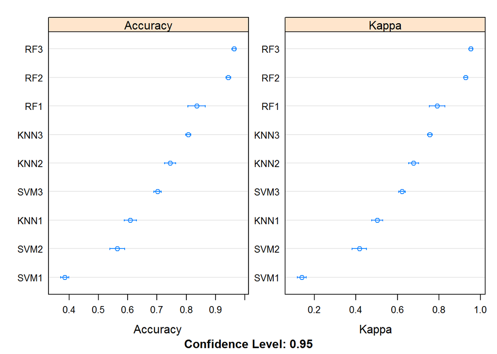

```r
results <- resamples(list(RF1=mf.rf.1ksample, RF2=mf.rf.3ksample, RF3=mf.rf.5ksample, KNN1=mf.knn.1ksample, KNN2=mf.knn.3ksample, KNN3=mf.knn.5ksample, SVM1=mf.svm.1ksample, SVM2=mf.svm.3ksample, SVM3=mf.svm.5ksample))
scales <- list(x=list(relation="free"), y=list(relation="free"))
dotplot(results, scales=scales)
```

The random forest model is the most accurate, even with a low ntree. A larger n does improve accuracy.

## 5. Prediction

Using the best model to test on the test set

```r
predict.rf.5ksample <- predict(mf.rf.5ksample, newdata=test)

#result stored in confustion matrix
confm <- confusionMatrix(table(test$classe, predict.rf.5ksample))
confm$overall[1] #accuracy is allright, even with ntree = 5
```

```
##  Accuracy
## 0.9783894
```

```r
#use the model on the 20 test cases
predict.final <- predict(mf.rf.5ksample, newdata=testcsv)
#final result
predict.final
```

```
##  [1] B A B A A E D B A A B C B A E E A D B B
## Levels: A B C D E
```

```r
#pretty final result
final_prediction <- transpose(data.frame(predict.final))
names(final_prediction) <- c(1:20)
final_prediction
```

```
##   1 2 3 4 5 6 7 8 9 10 11 12 13 14 15 16 17 18 19 20
## 1 B A B A A E D B A  A  B  C  B  A  E  E  A  D  B  B
```

## 6. Relationship Ntree and Accuracy?

Was wondering why Ntree is normally set to 500 when accuracy with a lower number produces reasonable results. Using an Ntree as low as possible seems to reduce computing time a lot.

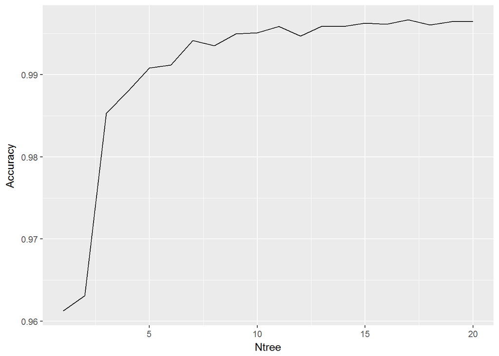

```r
ntreevsacc <- data.frame(matrix(ncol=3, nrow=1))

for(i in seq(1,20, by=1)){
   ntree <- i
   t <- system.time(mf.rf.fullset <- train(classe ~ ., data=train, method="rf", trControl=train_control, metric=metric, ntree=ntree))
   ntreevsacc[i,] <- list(ntree, round(max(mf.rf.fullset$results[,2]), digits = 5), t[1])
}

names(ntreevsacc) <- c("Ntree", "Accuracy", "Time")

gp <- ggplot(data=ntreevsacc, aes(x=Ntree, y=Accuracy)) + geom_line()
gp
```